# Processing of data comparing MagReSyn and SP3

### Description

- MGF files were generated using RawQuant.
- The data were searched using SearchCLI and PeptideShakerCLI.
- Raw files were parsed for quantification data with RawQuant.

### Analysis

First call the libraries that are required.

```r
library(Biostrings)
library(Rmisc)
library(dplyr)
library(ggplot2)
library(RColorBrewer)
library(cowplot)
library(tidyr)
#library(reshape)
library(data.table)
library(UpSetR)
library(stringr)
library(Peptides)
library(VennDiagram)
library(limma)
```

First thing we want to do is compile the identifications data into a usable object for plotting. This involves taking the output from PeptideShaker and combining it with the RawQuant data. This is carried out using the code below.

First I will compile the identification data.

```r
id_files = list.files('/projects/ptx_analysis/chughes/projects-current/sp3-follow-up/magresyn-testing/reports-output', pattern='.*Default_PSM_Report.txt',full.names=TRUE) #psm files
quant_files = list.files('/projects/ptx_analysis/chughes/projects-current/sp3-follow-up/magresyn-testing/quant-output', pattern='.*QuantData.txt',full.names=TRUE) #ms2 quant files
```

Read in the identification data into a single data frame object.

```r
id_parsed = data.frame() #identification data storage object
#iterate over the identification files
for (i in 1:length(id_files)){
  psm_in = read.table(id_files[i],header=TRUE,sep='\t') #input file
  psm_f1 = psm_in %>%
    dplyr::select(Protein.s., Sequence, Spectrum.File, Spectrum.Title, m.z, Identification.Charge) %>% #select columns
    dplyr::mutate(Spectrum.Title, scan_num = sub(".*?spectrum (.*?)", "\\1", Spectrum.Title)) %>% #parse out the scan number
    dplyr::mutate(Identification.Charge, id_charge = gsub("[^0-9]", "", Identification.Charge)) %>% #parse out the charge
    dplyr::mutate(Spectrum.Title, fraction = sub(".*?hph_(.*?)_MGF\\.mgf", "\\1", Spectrum.File)) %>% #parse the fraction
    dplyr::select(Protein.s., Sequence, scan_num, m.z, id_charge, fraction) %>% #select new columns
    dplyr::mutate(Protein.s., first_accession = sapply(strsplit(as.character(Protein.s.),"\\,"), `[`, 1)) #parse the accession
  #adjust the column names
  colnames(psm_f1) = c('accession_groups','sequence','ScanNumber','id_precursor_mz','id_charge','fraction','accession')
  psm_f2 = dplyr::filter(psm_f1, !grepl('CONT_', accession_groups)) #remove the contaminant proteins
  id_parsed = rbind(id_parsed,psm_f2) #group the data with the previously processed set
}
```

Now we can process the rawquant data for the TMT values.

```r
quant_parsed = data.frame()
#iterate over the rawquant files
for (i in 1:length(quant_files)){
  quant_in = read.table(quant_files[i],header=TRUE,sep='\t') #grab the input file
  #change values that are zero to NA
  quant_in[,15:50][quant_in[,15:50] == 0] = NA
  #rearrange the data frame
  quant_meta = quant_in[,c('PrecursorMass','ScanNumber','MS1ScanNumber','RetentionTime',
                           'PrecursorCharge','MS2IonInjectionTime','MS1Interference',
                           'tmt126_mass','tmt127N_mass','tmt128C_mass','tmt129N_mass','tmt130C_mass',
                           'tmt131_mass')]
  quant_exprs = quant_in[,c('tmt126_intensity','tmt127N_intensity','tmt128C_intensity',
                            'tmt129N_intensity','tmt130C_intensity','tmt131_intensity',
                            'tmt126_noise','tmt127N_noise','tmt128C_noise','tmt129N_noise','tmt130C_noise',
                            'tmt131_noise')]
  #calculate signal to noise
  quant_sn = quant_exprs[,c(1:6)] / quant_exprs[,c(7:12)] #signal-to-noise calculation
  quant_sn$totalIntensity = rowSums(quant_exprs[,1:6],na.rm=TRUE) #total intensity calculation
  quant_sn$totalSN = rowSums(quant_sn[,1:6],na.rm=TRUE) #total signal-to-noise calculation
  quant_sn$totalNoise = rowSums(quant_exprs[,7:12],na.rm=TRUE) #total noise calculation
  quant_sn$totalNA = rowSums(is.na(quant_sn[,1:6])) #information about missing values
  quant_meta$fraction = sub(".*?hph_(.*?)_Q.*", "\\1", quant_files[i]) #add the fraction column
  quant_matrix = cbind(quant_meta,quant_sn) #bind the information and quantification together
  quant_parsed = rbind(quant_parsed, quant_matrix) #bind into a single frame
}
```

Now we can combine the two data sets together using a simple merge and save the data.

```r
id_quant = merge(id_parsed, quant_parsed, by=c('ScanNumber', 'fraction'))
saveRDS(id_quant, '/projects/ptx_analysis/chughes/projects-current/sp3-follow-up/magresyn-testing/Routput/ch_feb2018_SP3-magresyn_id-quant-all.rds') #save the data
```

Now that I have the compiled data set, I want to plot how well the methods compare with one another. I can do this using their TMT intensities from rawquant.

```r
###first read in the data file I just prepared
psm_set = readRDS('/projects/ptx_analysis/chughes/projects-current/sp3-follow-up/magresyn-testing/Routput/ch_feb2018_SP3-magresyn_id-quant-all.rds') #read processed data
```

First, lets just make a boxplot of the intensities across all peptides to look at global recovery.

Collapse redundant psm’s in the data.

```r
psm_agg <- setDT(psm_set)[, lapply(.SD,sum,na.rm=TRUE),by=.(sequence,fraction),.SDcols=c('tmt126_intensity','tmt127N_intensity','tmt128C_intensity',
                                                                                          'tmt129N_intensity','tmt130C_intensity','tmt131_intensity')] #collapse by sequence and replicate
setDF(psm_agg) # convert back to dataframe
dim(psm_agg) #122867 rows are remaining
```

```
[1] 122867      8
```

Now plot the data in a boxplot.

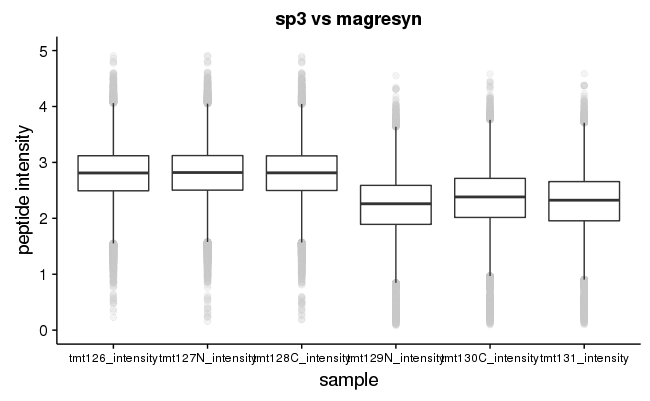

```r
peptides_melted = melt(psm_agg[,c(1,3:8)]) #melt the data to long format first
###now plot the data
magresyn_plot = ggplot(peptides_melted, aes(variable, log10(value))) +
    #geom_point(aes(fill=variable),position=position_jitterdodge(dodge.width=0.9),colour='grey60',alpha=0.1) +
    geom_boxplot(position=position_dodge(width=0.9),outlier.colour='gray80', outlier.size = 2, outlier.alpha = 0.2) +
    labs(x = "sample", y = 'peptide intensity', title = 'sp3 vs magresyn') +
    theme(axis.text.x = element_text(size = 9)) +
    #scale_y_continuous(limits=c(0,1.5e9)) +
    theme(legend.position="none") +
    #scale_fill_manual(values=brewer.pal(6,"Set3")[c(1,3:4)]) +
    scale_y_continuous(limits = c(0,5), breaks = seq(0,5,1))
magresyn_plot #call the plot
save_plot('/projects/ptx_analysis/chughes/projects-current/sp3-follow-up/magresyn-testing/Routput/ch_feb2018_SP3-magresyn_peptide-boxplot.pdf',magresyn_plot)
```

Interesting. The SP3 channels seem to be higher overall. What if we do a significance test on the means of the columns.

```r
sp3_means = colMeans(psm_agg[,3:5], na.rm=TRUE) #get the SP3 column means
magresyn_means = colMeans(psm_agg[,6:8], na.rm=TRUE) #get the magresyn column means
###perform a standard t-test on the means
sd(sp3_means)
```

```
[1] 9.392057
```

```r
sd(magresyn_means)
```

```
[1] 53.04743
```

```r
t.test(sp3_means, magresyn_means) #perform the t.test
```

```
    Welch Two Sample t-test

data:  sp3_means and magresyn_means
t = 23.092, df = 2.1253, p-value = 0.001372
alternative hypothesis: true difference in means is not equal to 0
95 percent confidence interval:
 591.7016 844.7912
sample estimates:
mean of x mean of y
1093.4991  375.2527
```

```r
t.test(sp3_means) #get the CI for SP3
```

```
    One Sample t-test

data:  sp3_means
t = 201.66, df = 2, p-value = 2.459e-05
alternative hypothesis: true mean is not equal to 0
95 percent confidence interval:
 1070.168 1116.830
sample estimates:
mean of x
 1093.499
```

```r
t.test(magresyn_means) #get the CI for magresyn
```

```
    One Sample t-test

data:  magresyn_means
t = 12.252, df = 2, p-value = 0.006595
alternative hypothesis: true mean is not equal to 0
95 percent confidence interval:
 243.4756 507.0298
sample estimates:
mean of x
 375.2527
```

So this appears to be significant. Now I want to look at identification overlap. For this I am going to filter the data based on a few criteria:

- the summed signal to noise across all channels must be greater than 100
- the number of NA values must be 3 or less
- signal values below a signal to noise of 10 will be set to zero

```r
##go back to the psm level data to filter
psm_filter1 = subset(psm_set, totalSN >= 100) #filter by signal to noise
psm_filter2 = subset(psm_filter1, totalNA <= 3) #filter by NA values
psm_filter2[, 20:25][psm_filter2[, 20:25] < 10] = NA #filter by signal to noise of individual channels

###now compile to peptides
psm_agg <- setDT(psm_filter2)[, lapply(.SD,sum,na.rm=TRUE),by=.(sequence),.SDcols=c('tmt126_intensity','tmt127N_intensity','tmt128C_intensity',
                                                                                          'tmt129N_intensity','tmt130C_intensity','tmt131_intensity')] #collapse by sequence and fraction
setDF(psm_agg) # convert back to dataframe
dim(psm_agg) #122434 rows are remaining
```

```
[1] 95794     7
```

Now, if we want to calculate peptides identified by only one method, we need to assign a threshold. Let’s say that a peptide has to reach a signal to noise above 30 and have just 1 NA value across the 3 replicate channels in order to be considered identifed.

```r
###need to convert values less than 10 to NA again, it gets reset
psm_agg[, 2:7][psm_agg[, 2:7] < 10] = NA #convert to NA values
psm_agg$sp3_signal = rowSums(psm_agg[,c(2:4)], na.rm=TRUE) #sum the SP3 signal
psm_agg$sp3_nas = rowSums(is.na(psm_agg[,c(2:4)])) #count SP3 NA values
psm_agg$magresyn_signal = rowSums(psm_agg[,c(5:7)], na.rm=TRUE) #sum the magresyn signal
psm_agg$magresyn_nas = rowSums(is.na(psm_agg[,c(5:7)])) #count magresyn NA values
###now count the identifications
psm_agg$sp3_id = ifelse((psm_agg$sp3_signal >= 30) & (psm_agg$sp3_nas <= 1), TRUE, FALSE)
psm_agg$magresyn_id = ifelse((psm_agg$magresyn_signal >= 30) & (psm_agg$magresyn_nas <= 1), TRUE, FALSE)
###look at the data
table(psm_agg$sp3_id, psm_agg$magresyn_id)
```

```
        FALSE  TRUE
  FALSE     0     1
  TRUE   1521 94272
```

```r
table(psm_agg$magresyn_id)
```

```
FALSE  TRUE
 1521 94273
```

Draw a Venn diagram of these data, even though I hate Venn diagrams.

```r
###draw a simple venn diagram
#unfortunately this wont display in the notebook...you have to spit it out to pdf
pdf('/projects/ptx_analysis/chughes/projects-current/sp3-follow-up/magresyn-testing/Routput/ch_feb2018_SP3-magresyn_peptide_venn.pdf')
draw.pairwise.venn(area1 = 122434, area2 = 120302, cross.area = 120302, category = c("MagReSyn", "SP3"))
```

```
(polygon[GRID.polygon.33102], polygon[GRID.polygon.33103], polygon[GRID.polygon.33104], polygon[GRID.polygon.33105], text[GRID.text.33106], text[GRID.text.33107], lines[GRID.lines.33108], text[GRID.text.33109], text[GRID.text.33110])
```

```r
dev.off()
```

Now I want to look at the properties of the peptides that are identified. How many missed cleavage peptides do we see?

```r
###use the aggregated peptide data for this
###look for missed cleavages
psm_agg$sub_sequence = str_sub(psm_agg$sequence,1,nchar(as.character(psm_agg$sequence)) - 1) #trim the final amino acid
psm_agg$missed = str_count(psm_agg$sub_sequence,'[RK]') #count the number of internal K or R
###output the data values
table(psm_agg$missed) / length(psm_agg$missed)
```

```
           0            1            2            3            4            5            6            7           10
8.319339e-01 1.542137e-01 1.310094e-02 6.370779e-04 4.900600e-05 2.450300e-05 1.633533e-05 1.633533e-05 8.167666e-06
```

So in line with what you would expect in a standard proteomics analysis. Because SP3 and MagReSyn are protein-level methods, I want to compare what proteins are found differently between the two approaches. First I need to make a protein set.

```r
###first filter the data using the same parameters as above
psm_filter1 = subset(psm_set, totalSN >= 100) #filter by signal to noise
psm_filter2 = subset(psm_filter1, totalNA <= 3) #filter by NA values
psm_filter2[, 20:25][psm_filter2[, 20:25] < 10] = NA #filter by signal to noise of individual channels
psm_filter2$number.of.peptides = 1 #add a peptide counter
###now compile to peptides
pro_agg <- setDT(psm_filter2)[, lapply(.SD,sum,na.rm=TRUE),by=.(accession),.SDcols=c('number.of.peptides','tmt126_intensity','tmt127N_intensity','tmt128C_intensity',
                                                                                          'tmt129N_intensity','tmt130C_intensity','tmt131_intensity')] #collapse by accession number
setDF(pro_agg) # convert back to dataframe
pro_set = subset(pro_agg, number.of.peptides > 1) #remove single peptide hits
dim(pro_set) #8109 rows are remaining
```

```
[1] 8109    8
```

Now determine identification overlap between the methods.

```r
##need to set the zero values to NA again, and then assign the ID TRUE/FALSE
pro_set[, 3:8][pro_set[, 3:8] < 10] = NA #filter by signal to noise of individual channels
#set up the parameters for counting the identifications
pro_set$sp3_signal = rowSums(pro_set[,c(3:5)], na.rm=TRUE) #sum the SP3 signal
pro_set$sp3_nas = rowSums(is.na(pro_set[,c(3:5)])) #count SP3 NA values
pro_set$magresyn_signal = rowSums(pro_set[,c(6:8)], na.rm=TRUE) #sum the magresyn signal
pro_set$magresyn_nas = rowSums(is.na(pro_set[,c(6:8)])) #count magresyn NA values
###now count the identifications
pro_set$sp3_id = ifelse((pro_set$sp3_signal >= 30) & (pro_set$sp3_nas <= 1), TRUE, FALSE)
pro_set$magresyn_id = ifelse((pro_set$magresyn_signal >= 30) & (pro_set$magresyn_nas <= 1), TRUE, FALSE)
#output the data
table(pro_set$sp3_id, pro_set$magresyn_id)
```

```
       FALSE TRUE
  TRUE     1 8108
```

```r
table(pro_set$sp3_id)
```

```
TRUE
8109
```

```r
table(pro_set$magresyn_id)
```

```
FALSE  TRUE
    1  8108
```

Now I want to look at differential expression between the proteins from the two methods. First the data need to be normalized because of the general overall higher recovery in the SP3 samples.

```r
#do some basic normalization
summary(pro_set[,3:8]) #look at the data to investigate normalization
```

```
 tmt126_intensity   tmt127N_intensity tmt128C_intensity  tmt129N_intensity   tmt130C_intensity   tmt131_intensity
 Min.   :    79.9   Min.   :    82    Min.   :    78.9   Min.   :    14.33   Min.   :    13.98   Min.   :    13.0
 1st Qu.:  2253.3   1st Qu.:  2293    1st Qu.:  2278.6   1st Qu.:   710.29   1st Qu.:   938.20   1st Qu.:   814.8
 Median :  6164.3   Median :  6252    Median :  6169.6   Median :  1925.29   Median :  2547.39   Median :  2218.6
 Mean   : 16495.7   Mean   : 16583    Mean   : 16305.5   Mean   :  4832.33   Mean   :  6429.71   Mean   :  5644.8
 3rd Qu.: 16907.7   3rd Qu.: 17105    3rd Qu.: 16774.8   3rd Qu.:  5061.53   3rd Qu.:  6697.99   3rd Qu.:  5868.6
 Max.   :631203.5   Max.   :625572    Max.   :617018.8   Max.   :210397.01   Max.   :238780.45   Max.   :229792.7
                                                         NA's   :1           NA's   :1           NA's   :2
```

```r
signal_sums = colSums(pro_set[,3:8],na.rm=TRUE) #sum the signals across all channels and store
#now loop over each of the columns taking the the proportion of the ion signal relative to the total multiplied by the median of all totals
for (l in 3:8){
        total_intensity = sum(pro_set[,l],na.rm=TRUE)
        pro_set[,l] = (pro_set[,l] / total_intensity) * median(signal_sums)
}
summary(pro_set[,3:8]) #look at the summary again...looks good after normalization
```

```
 tmt126_intensity tmt127N_intensity  tmt128C_intensity tmt129N_intensity  tmt130C_intensity  tmt131_intensity
 Min.   :    55   Min.   :    56.2   Min.   :    55    Min.   :    33.7   Min.   :    24.7   Min.   :    26.2
 1st Qu.:  1553   1st Qu.:  1571.5   1st Qu.:  1588    1st Qu.:  1671.0   1st Qu.:  1658.9   1st Qu.:  1641.1
 Median :  4248   Median :  4285.7   Median :  4301    Median :  4529.5   Median :  4504.1   Median :  4468.7
 Mean   : 11367   Mean   : 11367.2   Mean   : 11367    Mean   : 11368.6   Mean   : 11368.6   Mean   : 11370.0
 3rd Qu.: 11651   3rd Qu.: 11725.0   3rd Qu.: 11694    3rd Qu.: 11907.8   3rd Qu.: 11843.0   3rd Qu.: 11820.7
 Max.   :434963   Max.   :428818.1   Max.   :430148    Max.   :494982.8   Max.   :422196.5   Max.   :462858.1
                                                       NA's   :1          NA's   :1          NA's   :2
```

Now we can perform the differential expression analysis with limma.

```r
#calculate differential expression using limma
eset = as.matrix(log2(pro_set[,c(3:8)])) #log transform the expression data and transfer to a new object
design <- cbind(SP3=c(1,1,1,0,0,0),MAG=c(0,0,0,1,1,1)) #create the design matrix
fit <- lmFit(eset,design) #calculate the linear model of the expression values
```

```
Partial NA coefficients for 1 probe(s)
```

```r
cont.matrix <- makeContrasts(SP3vsMAG=SP3-MAG, levels=design) #create the contrasts matrix
fit2 <- contrasts.fit(fit, cont.matrix) #calculate the contrasts
fit2 <- eBayes(fit2) #empirical Bayes smoothing
logFC = fit2$coef #extract fold changes
pVal = fit2$p.value #extract p-values
p.adj = p.adjust(fit2$p.value, method="BH") #apply multiple testing correction to the p-values
#insert the data back into the original matrix
pro_set$logFC <- logFC
pro_set$p.value <- pVal
pro_set$p.adj.value <- p.adj
pro_ordered = pro_set[order(-pro_set$logFC),] #reorder the matrix by fold change
write.table(pro_ordered, '/projects/ptx_analysis/chughes/projects-current/sp3-follow-up/magresyn-testing/Routput/ch_feb2018_SP3-magresyn_id-quant-proteins.txt', sep = '\t', row.names = FALSE, col.names = TRUE, quote = FALSE)
```

Now we can plot the differential expression, for visualization purposes.

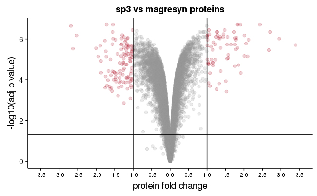

```r
#add a threshold for coloring signicant points
pro_ordered$threshold = as.factor((pro_ordered$p.adj.value < 0.05) & (pro_ordered$logFC < -1) | (pro_ordered$p.adj.value < 0.05) & (pro_ordered$logFC > 1)) #assign the threshold
#make the plot
sp3_scatter = ggplot(pro_ordered, aes(logFC, -log10(p.adj.value), color = threshold)) +
    geom_point(alpha=0.2,size=2) +
    labs(x = "protein fold change", y = '-log10(adj p value)', title = 'sp3 vs magresyn proteins') +
    theme(axis.text.x = element_text(size = 9)) +
    #scale_y_continuous(limits=c(0,1.5e9)) +
    geom_hline(yintercept = -log10(0.05)) +
    geom_vline(xintercept = 1) +
    geom_vline(xintercept = -1) +
    scale_color_manual(values=c('gray60',brewer.pal(6,"RdBu")[1])) +
    scale_x_continuous(limits = c(-3.5,3.5), breaks = seq(-4,4,0.5)) +
    theme(legend.position="none")
sp3_scatter #call the plot
save_plot('/projects/ptx_analysis/chughes/projects-current/sp3-follow-up/magresyn-testing/Routput/ch_feb2018_SP3-magresyn_peptide-scatter.pdf',sp3_scatter)
```

```r
#get the values
table((pro_ordered$p.adj.value < 0.05) & (pro_ordered$logFC < -1))
```

```
FALSE  TRUE
 7996   112
```

```r
table((pro_ordered$p.adj.value < 0.05) & (pro_ordered$logFC > 1))
```

```
FALSE  TRUE
 8039    69
```

Are there any interesting properties of these proteins?

```r
sp3_enriched = pro_set[(pro_ordered$p.adj.value < 0.05) & (pro_ordered$logFC > 1) & (!is.na(pro_ordered$logFC)),] #sp3 enriched proteins
mag_enriched = pro_set[(pro_ordered$p.adj.value < 0.05) & (pro_ordered$logFC < -1) & (!is.na(pro_ordered$logFC)),] #magresyn enriched proteins
#there seems to be one protein tagging along in both data sets that, add in the is.na command above to get rid of it
###write the data to a file to input to gProfiler
write.table(sp3_enriched, '/projects/ptx_analysis/chughes/projects-current/sp3-follow-up/magresyn-testing/Routput/ch_feb2018_SP3-magresyn_sp3-enriched.txt',col.names=TRUE, row.names=FALSE, quote = FALSE, sep = '\t')
write.table(mag_enriched, '/projects/ptx_analysis/chughes/projects-current/sp3-follow-up/magresyn-testing/Routput/ch_feb2018_SP3-magresyn_mag-enriched.txt',col.names=TRUE, row.names=FALSE, quote = FALSE, sep = '\t')
```

It seems there are some differences in the types of proteins that were found, specifically in relation to the number of peptides.

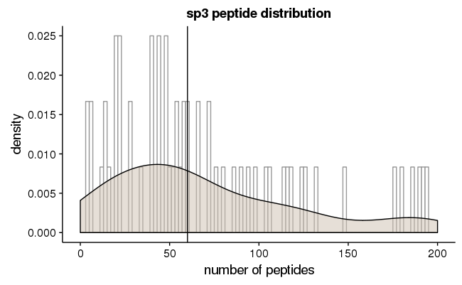

```r
###plotting these data on the same plot is messy...the data distributions are very different. Make separate plots
#sp3 plot
sp3_distplot = ggplot(sp3_enriched, aes(x = number.of.peptides)) +
  geom_histogram(aes(y = ..density..), binwidth = 2, color = "grey60", fill = "white") +
  geom_density(alpha = .5, fill = "antiquewhite3") +
  labs(x = "number of peptides", y = 'density', title = 'sp3 peptide distribution') +
  geom_vline(xintercept = median(sp3_enriched$number.of.peptides)) +
  scale_x_continuous(limits = c(0,200), breaks = seq(0,200,50))
sp3_distplot #call the plot
save_plot('/projects/ptx_analysis/chughes/projects-current/sp3-follow-up/magresyn-testing/Routput/ch_feb2018_SP3-magresyn_SP3-peptide-number-distribution.pdf',sp3_distplot)
```

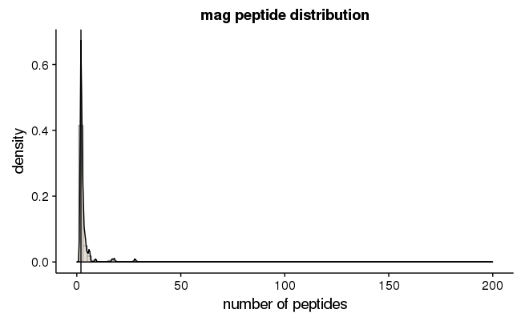

```r
#magresyn plot
mag_distplot = ggplot(mag_enriched, aes(x = number.of.peptides)) +
  geom_histogram(aes(y = ..density..), binwidth = 2, color = "grey60", fill = "white") +
  geom_density(alpha = .5, fill = "antiquewhite3") +
  labs(x = "number of peptides", y = 'density', title = 'mag peptide distribution') +
  geom_vline(xintercept = median(mag_enriched$number.of.peptides)) +
  scale_x_continuous(limits = c(0,200), breaks = seq(0,200,50))
mag_distplot #call the plot
save_plot('/projects/ptx_analysis/chughes/projects-current/sp3-follow-up/magresyn-testing/Routput/ch_feb2018_SP3-magresyn_MAG-peptide-number-distribution.pdf',mag_distplot)
```

```r
#output some values
median(sp3_enriched$number.of.peptides)
```

```
[1] 60
```

```r
median(mag_enriched$number.of.peptides)
```

```
[1] 2
```

What about other protein properties, like size, hydrophobicity?

```r
###for this we need the protein sequences. We can use our original database for this.
humanDB = readAAStringSet('/projects/ptx_analysis/chughes/databases/feb2018/uniprot_human-crap-feb2018_FWD.fasta')
#extract out the SP3 data of interest
sp3_data = data.frame()
for (i in 1:nrow(sp3_enriched)){
  accession_query = sp3_enriched$accession[i] #get the uniprot id
  accession_location = which(grepl(accession_query,names(humanDB))) #get the location of that sequence
  accession_length = nchar(as.character(unlist(humanDB[accession_location]))) #get the length of the protein
  accession_mw = mw(as.character(unlist(humanDB[accession_location]))) #get the mw of the protein
  accession_hydrophobicity = hydrophobicity(as.character(unlist(humanDB[accession_location])), scale='KyteDoolittle') #get the hydrophobicity
  #accession_type = membpos(as.character(unlist(humanDB[accession_location]))) #get the type
  sp3_data[i,1] = accession_query #output
  sp3_data[i,2] = accession_length #output
  sp3_data[i,3] = accession_mw #output
  sp3_data[i,4] = accession_hydrophobicity #output
  #sp3_data[i,5] = accession_type #output
  colnames(sp3_data) = c('name','length','mw','hydro') #annotation
}
#extract out the MAG data of interest
mag_data = data.frame()
for (i in 1:nrow(mag_enriched)){
  accession_query = mag_enriched$accession[i] #get the uniprot id
  accession_location = which(grepl(accession_query,names(humanDB))) #get the location of that sequence
  accession_length = nchar(as.character(unlist(humanDB[accession_location]))) #get the length of the protein
  accession_mw = mw(as.character(unlist(humanDB[accession_location]))) #get the mw of the protein
  accession_hydrophobicity = hydrophobicity(as.character(unlist(humanDB[accession_location])), scale='KyteDoolittle') #get the hydrophobicity
  #accession_type = membpos(as.character(unlist(humanDB[accession_location]))) #get the type
  mag_data[i,1] = accession_query #output
  mag_data[i,2] = accession_length #output
  mag_data[i,3] = accession_mw #output
  mag_data[i,4] = accession_hydrophobicity #output
  #mag_data[i,5] = accession_type #output
  colnames(mag_data) = c('name','length','mw','hydro') #annotation
}
```

Now we can plot these data for the protein MW.

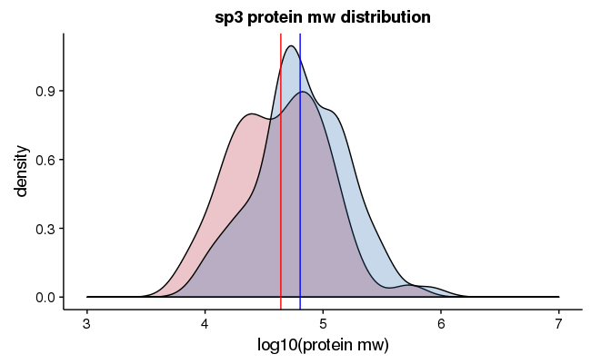

```r
###add a category for each data set
sp3_data$dataset = 'sp3'
mag_data$dataset = 'mag'
sp3_mag_data = rbind(sp3_data,mag_data)
##now plot the melted data
both_distplot = ggplot(sp3_mag_data, aes(x = log10(mw), fill = dataset)) +
  geom_histogram(aes(y = ..density..), binwidth = 20, position = "identity") +
  geom_density(alpha = 0.25) +
  labs(x = "log10(protein mw)", y = 'density', title = 'sp3 protein mw distribution') +
  geom_vline(xintercept = median(log10(sp3_data$mw)), color = 'blue') +
  geom_vline(xintercept = median(log10(mag_data$mw)), color = 'red') +
  scale_x_continuous(limits = c(3,7), breaks = seq(3,7,1)) +
  scale_fill_manual(values = brewer.pal(6,'RdBu')[c(1,6)]) +
  theme(legend.position="none")
both_distplot #call the plot
save_plot('/projects/ptx_analysis/chughes/projects-current/sp3-follow-up/magresyn-testing/Routput/ch_feb2018_SP3-magresyn_both-protein-size-distribution.pdf',both_distplot)
```

```r
#output some data
median(log10(sp3_data$mw))
```

```
[1] 4.805807
```

```r
median(log10(mag_data$mw))
```

```
[1] 4.642426
```

We can also plot the hydrophobicity scores.

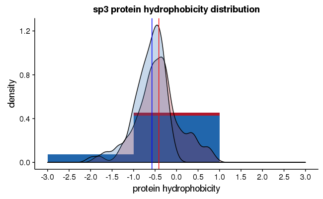

```r
##plot the hydro data
both_distplot = ggplot(sp3_mag_data, aes(x = hydro, fill = dataset)) +
  geom_histogram(aes(y = ..density..), binwidth = 2, position = "identity") +
  geom_density(alpha = 0.25) +
  labs(x = "protein hydrophobicity", y = 'density', title = 'sp3 protein hydrophobicity distribution') +
  geom_vline(xintercept = median(sp3_data$hydro), color = 'blue') +
  geom_vline(xintercept = median(mag_data$hydro), color = 'red') +
  scale_x_continuous(limits = c(-3,3), breaks = seq(-3,3,0.5)) +
  scale_fill_manual(values = brewer.pal(6,'RdBu')[c(1,6)]) +
  theme(legend.position="none")
both_distplot #call the plot
save_plot('/projects/ptx_analysis/chughes/projects-current/sp3-follow-up/magresyn-testing/Routput/ch_feb2018_SP3-magresyn_both-protein-hydro-distribution.pdf',both_distplot)
```

```r
#output some data
median(sp3_data$hydro)
```

```
[1] -0.5726852
```

```r
median(mag_data$hydro)
```

```
[1] -0.4121157
```

Lastly, what about amino acid composition?

```r
#extract out the SP3 data of interest
sp3_comp = data.frame(empty_column=0) #make a dummy data frame
for (i in 1:nrow(sp3_enriched)){
  accession_query = sp3_enriched$accession[i] #get the uniprot id
  accession_location = which(grepl(accession_query,names(humanDB))) #get the location of that sequence
  accession_comp = as.data.frame(aaComp(as.character(unlist(humanDB[accession_location])))) #get the composition
  sp3_comp = cbind(sp3_comp, accession_comp[,1])
  row.names(sp3_comp) = row.names(accession_comp)
}
#extract out the MAG data of interest
mag_comp = data.frame(empty_column=0) #make a dummy data frame
for (i in 1:nrow(mag_enriched)){
  accession_query = mag_enriched$accession[i] #get the uniprot id
  accession_location = which(grepl(accession_query,names(humanDB))) #get the location of that sequence
  accession_comp = as.data.frame(aaComp(as.character(unlist(humanDB[accession_location])))) #get the composition
  mag_comp = cbind(mag_comp, accession_comp[,1])
  row.names(mag_comp) = row.names(accession_comp)
}
###now process the data to totals
sp3_totals = rowSums(sp3_comp[,2:70],na.rm=TRUE) #sp3 totals
mag_totals = rowSums(mag_comp[,2:113],na.rm=TRUE) #mag totals
#normalize the totals to percent
sp3_percents = (sp3_totals / sum(sp3_totals)) *100
mag_percents = (mag_totals / sum(mag_totals)) *100
#now prepare the data to plot
sp3_melted = melt(sp3_percents) #melt the data
sp3_melted$dataset = 'sp3' #add dataset identifier
mag_melted = melt(mag_percents) #melt the data
mag_melted$dataset = 'mag' #add dataset identifier
sp3_mag_comp = rbind(sp3_melted,mag_melted) #bind the data
sp3_mag_comp$type = rep(row.names(sp3_mag_comp)[1:9],2) #get identifiers
```

Now plot the composition data.

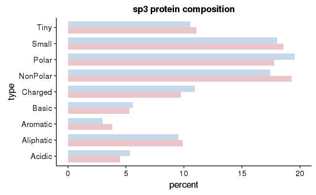

```r
comp_barplot = ggplot(sp3_mag_comp, aes(type, value, fill = dataset)) +
  geom_col(width=0.75, position = position_dodge(width=0.75), alpha = 0.25) +
  theme(legend.position="none") +
  labs(x = "type", y = 'percent', title = 'sp3 protein composition') +
  scale_fill_manual(values=brewer.pal(6,"RdBu")[c(1,6)]) +
  scale_y_continuous(limits = c(0,20), breaks = seq(0,20,5)) +
  coord_flip()
comp_barplot #call the plot
save_plot('/projects/ptx_analysis/chughes/projects-current/sp3-follow-up/magresyn-testing/Routput/ch_feb2018_SP3-magresyn_both-protein-comp-distribution.pdf',comp_barplot)
```

Done.